# Introduction to Python

## What is Python?

- High-level, interpreted language
- Known for its simplicity and readability
- Widely used in web development, data analysis, artificial intelligence, and more

## Python vs. R: Key Differences

- **Purpose**: Python is a general-purpose language, while R was specifically designed for statistics and data analysis.
- **Syntax**: Python emphasizes readability and simplicity; R has a steeper learning curve for those not familiar with programming.
- **Community**: Python has a broader community, while R's community is highly specialized in statistics and data science.

## Python's Philosophy

Python emphasizes readability and simplicity in programming. The language's core philosophy includes several guiding principles:

- **Beautiful is better than ugly:** Code should be aesthetically pleasing.
- **Explicit is better than implicit:** Clarity is key.
- **Simple is better than complex:** Favor simple solutions.
- **Readability counts:** Write code that others can easily read and understand.

## Code Quality!

### Code Formatters

- **Black**: A *highly* opinionated formatter that reformats your code into a consistent style.

  > "Any color you like."
- **autopep8**: Automatically formats Python code to conform to the PEP 8 style guide.
- **isort**: Sorts imports alphabetically and automatically separated into sections and by type.

### Linters

- **Flake8**: A tool that checks the style and quality of Python code to help you write clean code.
- **Pylint**: Analyzes Python code for errors and enforces a coding standard.

```python
import json,os,sys,time
from typing import Any
def calc_sum(lst):
    return sum(lst)
def manipulate_sum(result):
    return result*2-3*3
numbers=[1,2,3]
total=calc_sum(numbers)
print(manipulate_sum(total))
```

```
3
```

```python
def calc_sum(lst: list[int]) -> int:
    """
    Calculate the sum of a list of integers.

    Args:
        lst (list[int]): The list of integers.

    Returns:
        int: The sum of the integers in the list.
    """
    return sum(lst)


def manipulate_sum(result: int) -> int:
    """
    Manipulate the result by multiplying it by 2 and subtracting 9.

    Args:
        result (int): The result to manipulate.

    Returns:
        int: The manipulated result.
    """
    return result * 2 - 3 * 3


numbers = [1, 2, 3]
total = calc_sum(numbers)
print(manipulate_sum(total))
```

```
3
```

## Python Applications

- Web Development (Django, Flask)
- Data Analysis (Pandas, NumPy)
- Machine Learning (PyTorch, TensorFlow, scikit-learn)
- Automation and Scripting
- Scientific Computing
- Data Visualization (Matplotlib, Seaborn, Plotly)

[interactive chart not shown]

## Getting Started with Google Colab

- A beginner's guide to using Google's cloud-based Jupyter notebook environment.
- **Free access to GPUs**: Useful for machine learning tasks.
- **No setup required**: Write and execute code directly.
- **Easy sharing**: Just like Google Docs, you can share your Colab notebooks with others.

## Creating a New Notebook

1. Go to [Google Colab](https://colab.research.google.com).
2. Click on `New Notebook` to create a new notebook.
3. A new notebook will open with an empty cell.

You can start typing Python code directly into the cells!

## Writing and Running Code

To write and execute Python in Colab:

1. Click on a cell to start typing code.
2. Press `Shift + Enter` to run the code in the cell.
3. The output will appear right below the cell.

## Data Types and Structures

- **Integers**: Whole numbers without a fractional part.
- **Floats**: Numbers that contain a decimal point.
- **Strings**: A sequence of characters.
- **Booleans**: True or False values.

## Complex Data Structures

- **Lists**: Ordered and mutable collection of items (similar to R lists).
- **Tuples**: Ordered and immutable collection of items.
- **Dictionaries**: Unordered collection of key-value pairs (similar to R lists with named elements).
- **Sets**: Unordered collection of unique elements.

## Some examples

```python
# Integers and Floats
x = 10      # Default integer
y = 2.5     # Default floating point

# Strings
name = "John Doe"

# Booleans
is_valid = True

# Lists
fruits = ["apple", "banana", "cherry"]

# Accessing list elements and printing with string interpolation
print(f"This is the first fruit: {fruits[0]}")

# Dictionaries
person = {"name": "John", "age": 30}
print(f"This is the person's name: {person['name']}")
```

```
This is the first fruit: apple
This is the person's name: John
```

## Indexing and Slicing

- Zero-based indexing
- Negative indices for reverse order
- Slicing to extract portions of a list

```python
# Indexing
numbers = [0, 1, 2, 3, 4, 5]
print(numbers[0])   # First element
print(numbers[-1])  # Last element

# Slicing
print(numbers[2:5]) # From 3rd to 5th element
print(numbers[:3])  # First three elements
print(numbers[-3:]) # Last three elements
```

```
0
5
[2, 3, 4]
[0, 1, 2]
[3, 4, 5]
```

## Control Flow

```python
# If-Else
x = 10
y = 20

if x > y:
    print("x is greater than y")
elif x < y:
    print("x is less than y")
else:
    print("x and y are equal")
```

```
x is less than y
```

## Control Structures: Looping

- `for` loops for iterating over sequences
- `while` loops for repeated execution as long as a condition is met
- Comprehensions for concise loop constructs
  - Very "Pythonic" way of writing loops

```python
# List comprehension -- similar to lapply in R
squares = [x**2 for x in range(10)]
print(squares)

# Dictionary comprehension
names = ['Alice', 'Bob', 'Charlie']
name_lengths = {name: len(name) for name in names}

print(name_lengths)
print(f"Length of Alice's name: {name_lengths['Alice']}")
```

```
[0, 1, 4, 9, 16, 25, 36, 49, 64, 81]
{'Alice': 5, 'Bob': 3, 'Charlie': 7}
Length of Alice's name: 5
```

```python
def add(x, y):
    return x + y

# We can call the function within an f-string!
print(f"1 + 2 = {add(1, 2)}")
```

```
1 + 2 = 3
```

## Working with Libraries

Google Colab comes with many popular Python libraries pre-installed, making it easy to get started with data analysis and visualization.

### Pre-installed Libraries

- **NumPy**: For numerical computing.
- **Pandas**: For data manipulation and analysis.
- **Matplotlib**: For creating visualizations.

### Installing Additional Libraries

If you need a library that is not pre-installed, you can install it using `pip`: Python's package manager.

```python
%%script false --no-raise-error

!pip install LIBRARY_NAME
```

## Importing Libraries

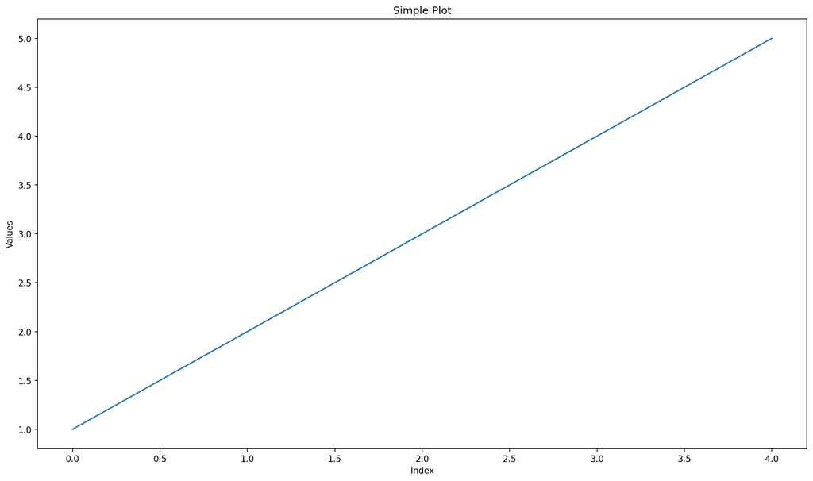

```python
import numpy as np
import pandas as pd
import matplotlib.pyplot as plt

# Using NumPy to create an array
arr = np.array([1, 2, 3, 4, 5])

# Creating a DataFrame with Pandas
df = pd.DataFrame(arr, columns=['Numbers'])

# Plotting with Matplotlib
plt.subplots(figsize=(16,9),dpi=150)  # Adjusted figure size to be larger
plt.plot(arr)
plt.title('Simple Plot')
plt.xlabel('Index')
plt.ylabel('Values')
plt.show()
```